# Exploratory Data Analysis Assignment2

Solution 3:-

1. Single Batch n=120

0.4 + 0.007* n= 0.4+ 0.007 * 120= 1.24

2. Two batches n=60

a= 0.4+0.007*n= 0.4+0.42=0.82

Similarly,b= 0.82

Total outside values= a+b= 0.82+0.82= 1.64

3. n=40

a= 0.4+ 0.007* 40= 0.68

n=30

b= 0.4+ 0.007* 30= 0.61

n=20

c= 0.4+0.007* 20= 0.54

n=10

c= 0.4+0.007* 10= 0.47

n=5

c= 0.4+ 0.007*5= 0.435

Total outside value= 0.68 + 0.61 + 0.54 + 0.47 + 4* 0.435 = 4.04

Solution 4

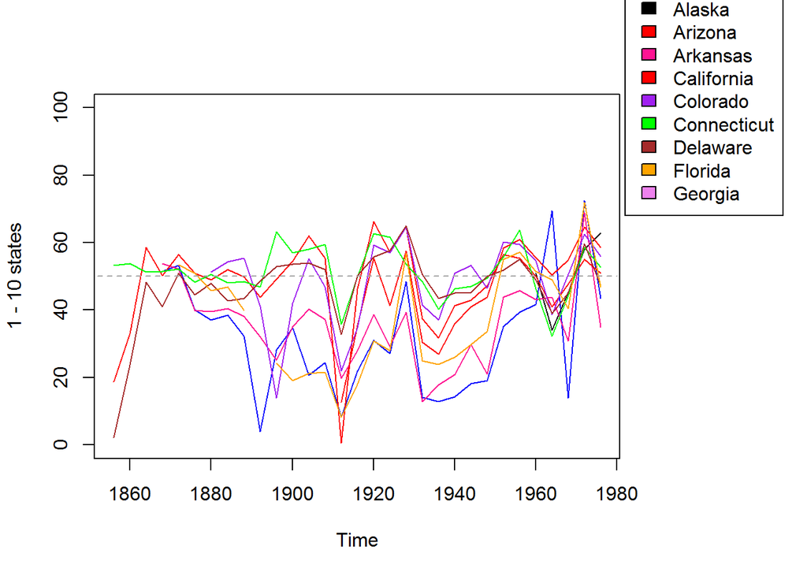

```r
library(cluster)
vote=votes.repub
vote_calc= function(vote,lower,upper)
{
  colours=c("blue","black","red","deeppink","red","purple","green","brown",
            "orange","violet")
  par(xpd=NA,oma=c(0,0,0,6))
  for(i in lower:upper)
  {
    vote_t=vote[i,]
    vote_t=as.data.frame(t(vote_t))
    vote_ts=ts(vote_t,frequency=0.25,start=1856)
    if(i==lower)
    {
      plot(vote_ts,col=colours[1],ylim=range(0,100),xlim=range(1856,1976),
           ylab=paste(lower,"-",upper,"states"))
    }
    else
      lines(vote_ts,col=colours[i%%10])
  }
  legend(1982,150,legend=row.names(vote[lower:upper,]),
         fill=colours,title="States")
  segments(1852,50,1980,50,col="grey65",lty=2)
}
vote_calc(vote,1,10)
```

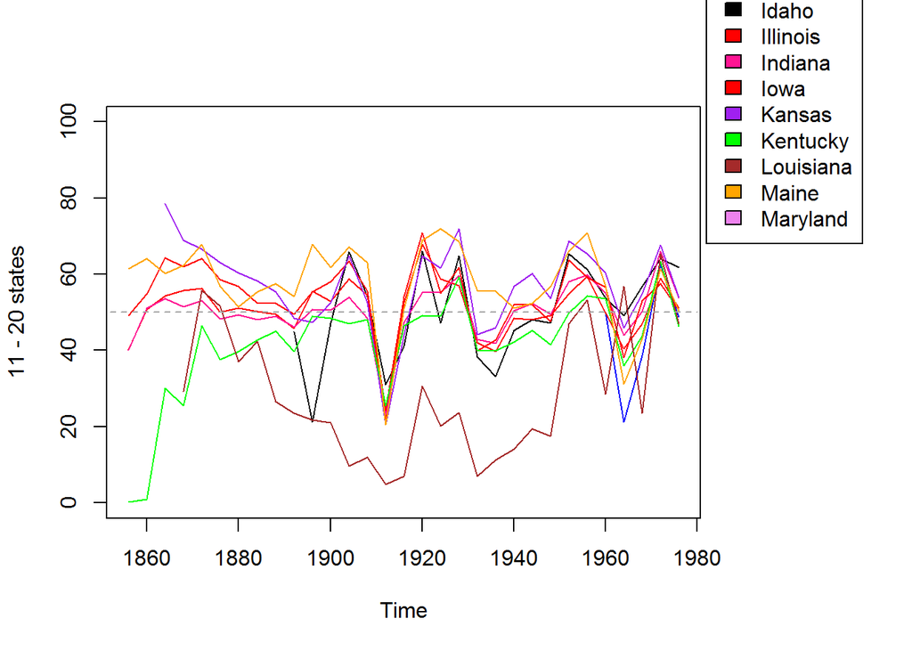

```r
vote_calc(vote,11,20)
```

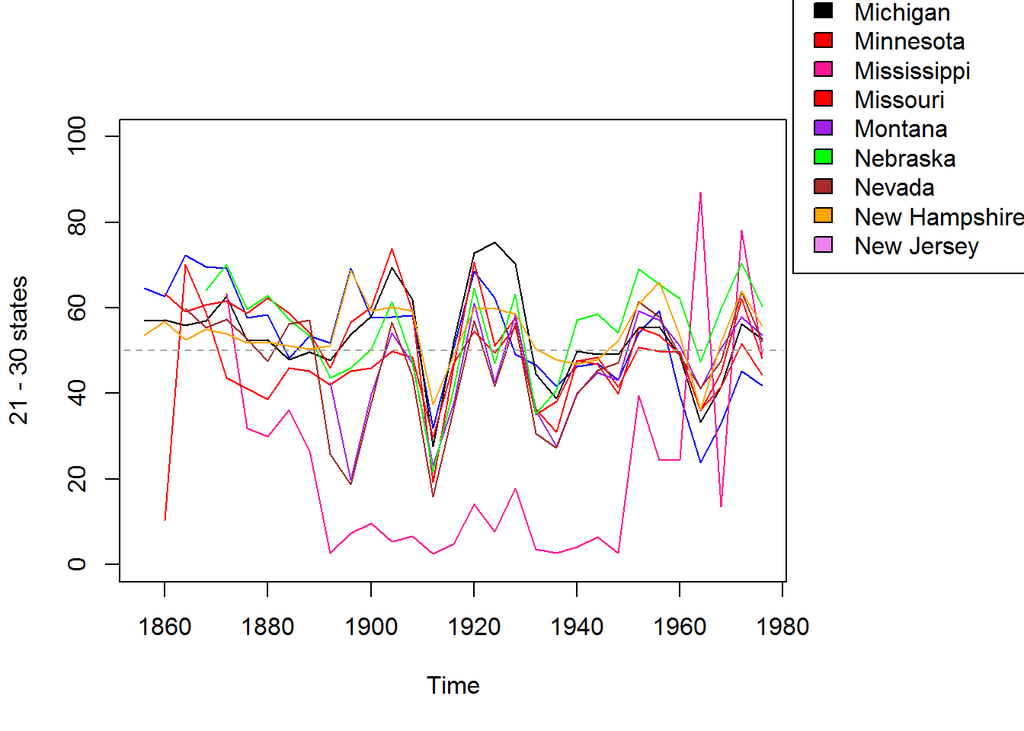

```r
vote_calc(vote,21,30)
```

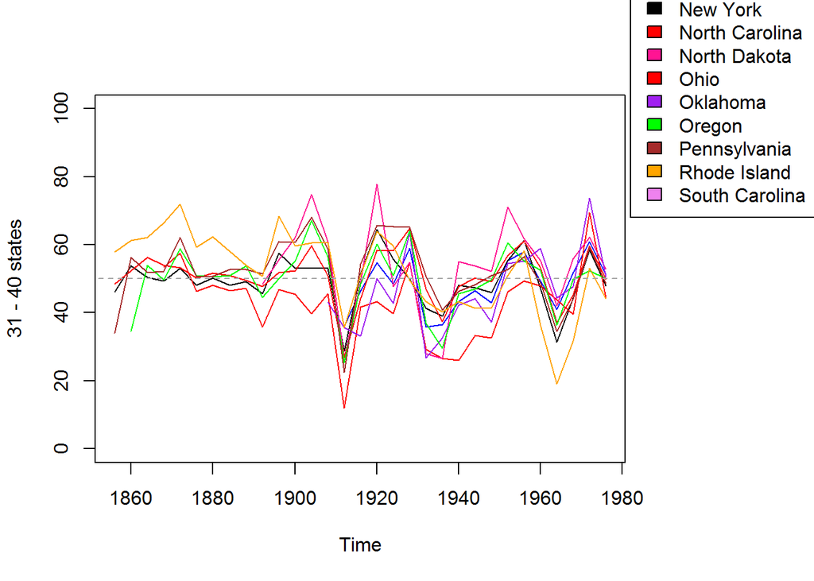

```r
vote_calc(vote,31,40)
```

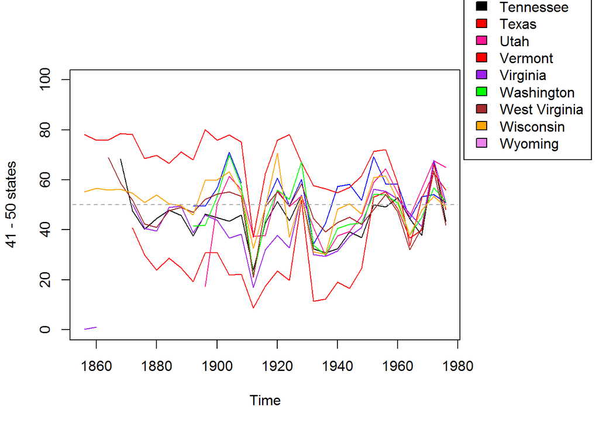

```r
vote_calc(vote,41,50)
```

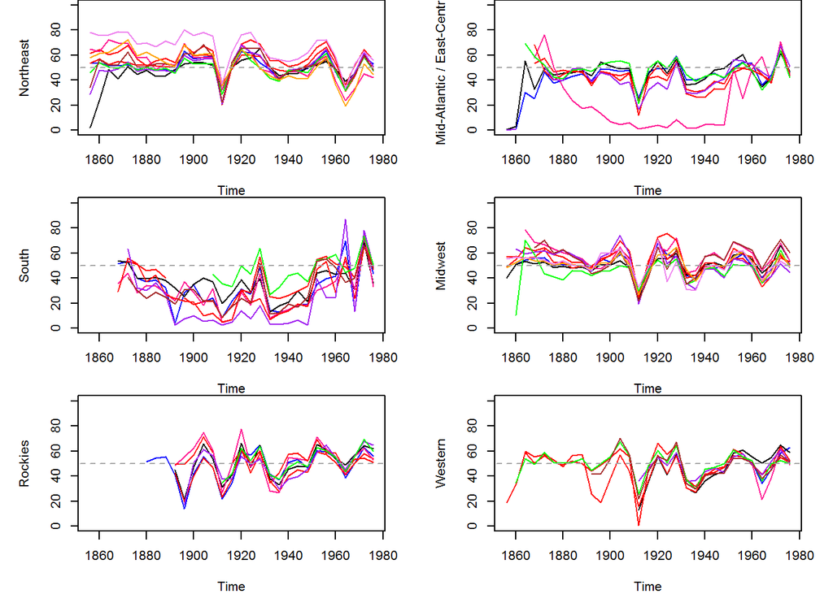

```r
library(cluster)
vote = votes.repub
par(mfrow = c(3, 2))
vote_calc = function(vote, reg, name)
{

  colours=c("blue","black","red","deeppink","red","purple","green","brown",
            "orange","violet")
  par(mar=c(4,5,0,2))
  j = 1
  for(i in reg)
  {
    vote_t = vote[i,]
    vote_t = as.data.frame(t(vote_t))
    vote_ts = ts(vote_t, frequency = 0.25, start = 1856)
    if(i==reg[1])
    {
      plot(vote_ts, col = colours[1], ylim = range(0,100),
           ylab = name)
    }
    else
      j = j + 1
    lines(vote_ts, col = colours[j])
  }
  segments(1852,50,1980,50, col = "grey65", lty = 2)
}

northeast = c("Connecticut","Delaware","Maine", "Massachusetts","New Hampshire","New Jersey",
              "New York","Pennsylvania","Rhode Island","Vermont")
east_central = c("Kentucky","Maryland","North Carolina","South Carolina","Tennessee",
                 "Virginia","West Virginia")
south = c("Alabama", "Arkansas", "Florida", "Georgia","Louisiana","Mississippi","Oklahoma","Texas")
midwest = c("Illinois","Indiana","Iowa","Kansas","Michigan","Minnesota","Missouri","Nebraska",
            "Ohio","Wisconsin")
rockies = c("Colorado","Idaho","Montana","North Dakota","South Dakota","Utah","Wyoming")
west = c("Alaska","Arizona","California","Hawaii","Nevada","New Mexico","Oregon","Washington")

vote_calc(vote, northeast, "Northeast")
vote_calc(vote, east_central, "Mid-Atlantic / East-Central")
vote_calc(vote, south, "South")
vote_calc(vote, midwest, "Midwest")
vote_calc(vote, rockies, "Rockies")
vote_calc(vote, west, "Western")
```

Republicans recieved less votes from South.

3).

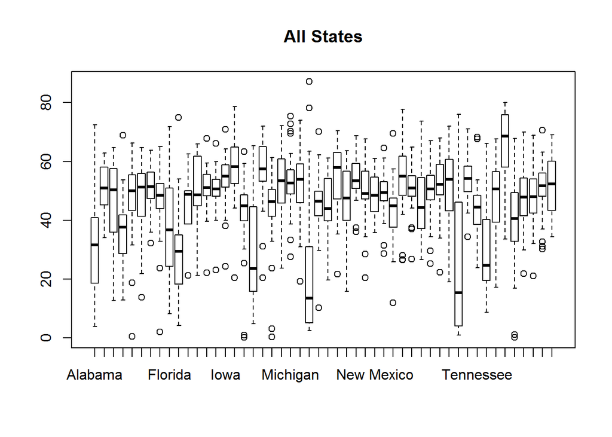

```r
library(cluster)
vote = votes.repub
par(mfrow = c(3, 2))
vote_calc = function(vote, reg, name)
{

  colours=c("blue","black","red","deeppink","red","purple","green","brown",
            "orange","violet")
  par(mar=c(4,5,0,2))
  j = 1
  for(i in reg)
  {
    vote_t = vote[i,]
    vote_t = as.data.frame(t(vote_t))
    vote_ts = ts(vote_t, frequency = 0.25, start = 1856)
    if(i==reg[1])
    {
      plot(vote_ts, col = colours[1], ylim = range(0,100),
           ylab = name)
    }
    else
      j = j + 1
    lines(vote_ts, col = colours[j])
  }
  segments(1852,50,1980,50, col = "grey65", lty = 2)
}

northeast = c("Connecticut","Delaware","Maine", "Massachusetts","New Hampshire","New Jersey",
              "New York","Pennsylvania","Rhode Island","Vermont")
east_central = c("Kentucky","Maryland","North Carolina","South Carolina","Tennessee",
                 "Virginia","West Virginia")
south = c("Alabama", "Arkansas", "Florida", "Georgia","Louisiana","Mississippi","Oklahoma","Texas")
midwest = c("Illinois","Indiana","Iowa","Kansas","Michigan","Minnesota","Missouri","Nebraska",
            "Ohio","Wisconsin")
rockies = c("Colorado","Idaho","Montana","North Dakota","South Dakota","Utah","Wyoming")
west = c("Alaska","Arizona","California","Hawaii","Nevada","New Mexico","Oregon","Washington")

# Box Plot for All States
par(mfrow=c(1,1))
boxplot(t(votes.repub), main ="All States")
```

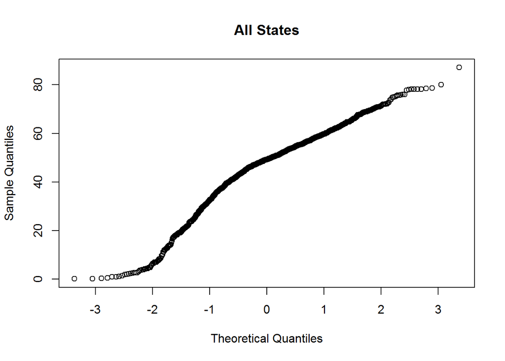

```r
qqnorm(t(votes.repub), main ="All States")
```

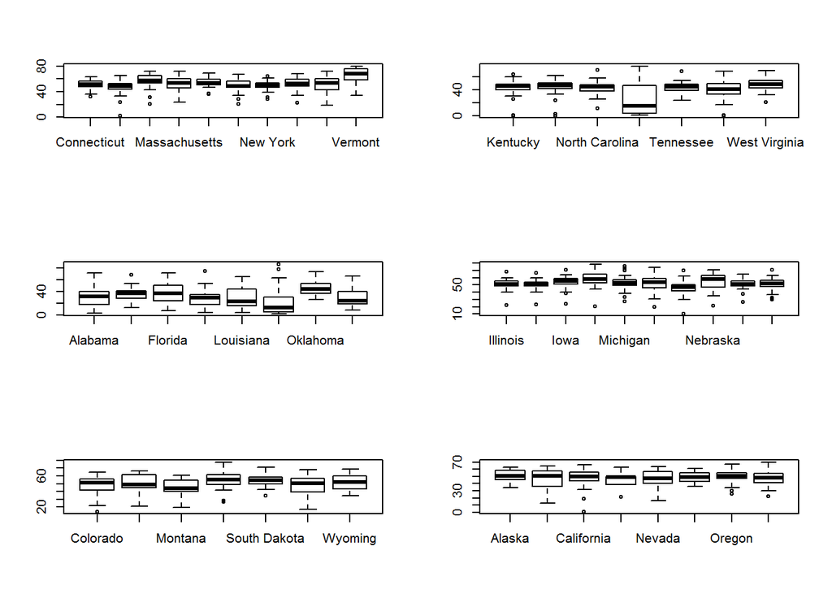

```r
par(mfrow=c(3,2))
# Box Plot for Northwest
boxplot(t(votes.repub[northeast,]))

# Box Plot for East central
boxplot(t(votes.repub[east_central,]))

#Box Plot for South
boxplot(t(votes.repub[south,]))

#Box Plot for Midwest
boxplot(t(votes.repub[midwest,]))

# Box Plot for Rockies
boxplot(t(votes.repub[rockies,]))

# Box Plot for West
boxplot(t(votes.repub[west,]))
```

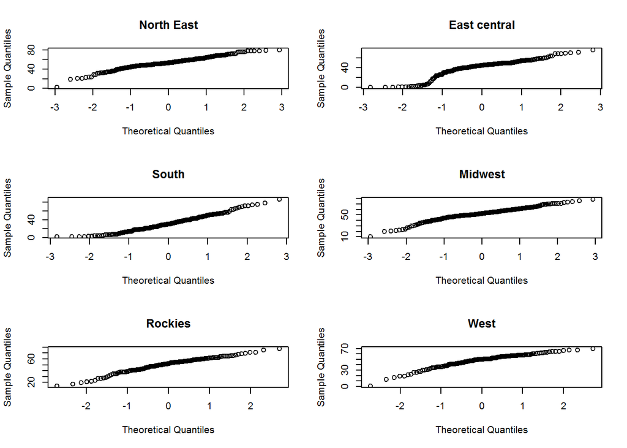

```r
par(mfrow=c(3,2))
qqnorm(t(votes.repub[northeast,]), main ="North East")
qqnorm(t(votes.repub[east_central,]), main = "East central")
qqnorm(t(votes.repub[south,]), main="South")
qqnorm(t(votes.repub[midwest,]), main="Midwest")
qqnorm(t(votes.repub[rockies,]), main="Rockies")
qqnorm(t(votes.repub[west,]), main="West")
```